# Projet OpenData

## Les accidents de la route graves et mortels en France

*FACCI Aurélien et NGUYEN Alexandre*

Chaque année sur les routes, il y a des accidents. Ceux-ci peuvent avoir plusieurs causes : état du conducteur, conditions météorologiques, état de la route ou encore une mauvaise manoeuvre. Cela cause à la fois des dégâts matériels pour les véhicules et les infrastructures routières, mais également des dégâts physiques aux personnes impliquées dans ces accidents. Malheureusement, il arrive que le choc de l'accident ou les blessures qui en découlent entraînent la mort d'une ou plusieurs personnes impliquées dans l'accident.  
Dans ce projet nous allons exploiter des données ouvertes sur les accidents de la route disponibles sur le site [data.gouv](https://www.data.gouv.fr/fr/datasets/bases-de-donnees-annuelles-des-accidents-corporels-de-la-circulation-routiere-annees-de-2005-a-2021/). Nous allons nous concentrer sur les accidents entraînant des blessures graves ou des morts en France métropolitaine. Notre objectif est de déterminer dans un premier temps quels sont les facteurs qui peuvent expliquer la survenue de ces types d'accidents. Ensuite nous tenterons à partir de ces données de prédire le taux de mortalité des accidents de la route en 2023.

### Sommaire

1. Données ouvertes utilisées
2. Statistiques descriptives
1. Nombre total d'accidents sur la période 2005-2021
2. Nombre d'accidents graves ou mortels pendant la période 2005-2021
3. Nombre d'usagers impliqués dans les accidents
4. Proportion d'hommes et de femmes dans les différents types d'accident
3. Régression logistique
1. Sélection préalable des variables
2. Analyse par rapport à la variable réponse binaire
3. Régression logistique sur R
4. Analyse en Composantes Multiples (ACM)
5. Prédiction du taux de mortalité
6. Conclusion

## 1. Données ouvertes utilisées

Comme dit en introduction, nous avons utilisé les données provenant du site [Data.gouv.fr](https://www.data.gouv.fr/fr/datasets/bases-de-donnees-annuelles-des-accidents-corporels-de-la-circulation-routiere-annees-de-2005-a-2021/) en ce qui concerne les accidents de la route. Les données recensent les accidents de la route des années 2005 à 2021 et pour chaque année, se décomposent en 4 fichiers csv. Chaque accident possède dans ces 4 fichiers un identifiant unique.

- caracteristiques : contient les caractéristiques de chaque accident à savoir la date, l'heure, le lieu (département, commune, adresse, lattitude, longitude, si c'est en agglomération ou non et le type d'intersection), des conditions météorologiques ainsi que le type de collision ;
- usagers : les identifiants des véhicules impliqués, des caractéristiques sur les usagers (âge, sexe, s'ils sont piéton ou conducteurs), la gravité de l'accident (si ça occasionne des blessures légères, graves ou une mort) et d'autres variables sur le contexte dans lequel étaient les usagers au moment de l'accident ;
- vehicules : des caractéristiques des véhicules impliqués dans l'accident ainsi que des caractéristiques de la collision ;
- lieux : des caractéristiques de la route où s'est déroulé l'accident comme le type de route (autoroute, route nationale, etc.), sa pente ou encore les infrastructures routières présents.

Egalement, nous avons utilisé des données recensant la population en France (métropolitaine et d'outre-mer) disponibles sur [le site internet de l'INSEE](https://www.insee.fr/fr/statistiques/1893198). Celles-ci nous ont permis de rapporter certaines statistiques à l'échelle de la population par année.

## 2. Statistiques descriptives

Avant toute chose nous nous sommes intéressés à l'évolution du nombre d'accidents par année pendant la période allant de 2005 à 2021.

### 2.A. Nombre total d'accidents sur la période 2005-2021

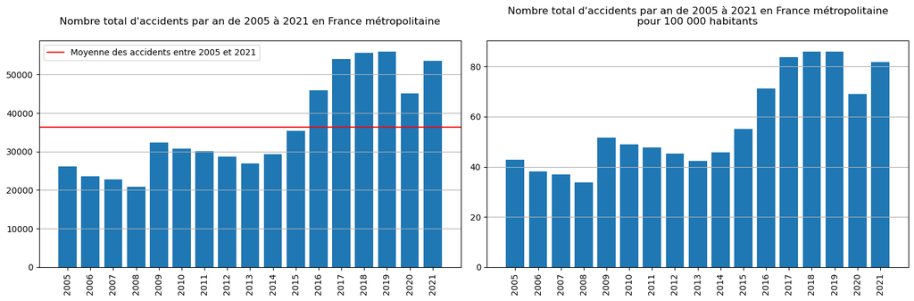

Nous pouvons voir qu'au fil des années, le nombre d'accidents a tendance à augmenter. Cela peut avoir de multiples causes : soit des conditions routières, sociales ou météorologiques ont permis cela, soit cela vient d'un manque de données pour les premières années.  
De plus, si nous rapportons le nombre d'accidents à la population pour chaque année, on s'aperçoit que ce nombre est peu élevé. Le maximum étant 86 accidents pour 100 000 habitants en 2019.  
À noter que nous avons rapporté à toute la population de France métropolitaine. En effet tout le monde peut être concerné dans un accident, que ce soit un nouveau né ou une personne d'un âge très avancé (né au début des années 1900), étant donné que les accidents recensés ne concernent pas que les voitures/camions et leurs conducteurs.  
Nous nous sommes ensuite intéressés à l'évolution du nombre d'accidents par mois pour avoir une évolution plus précise.

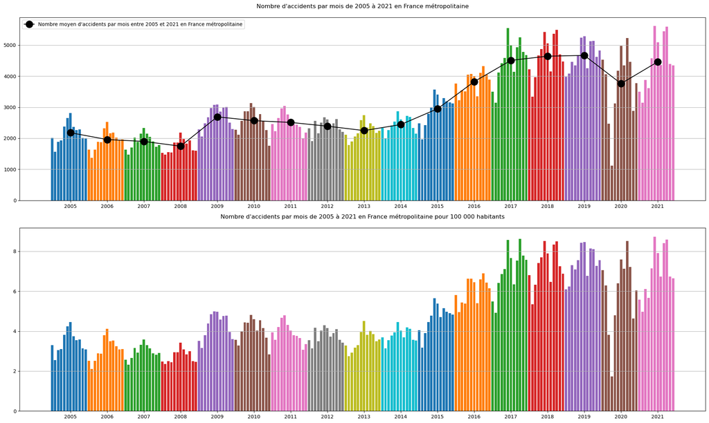

### 2.B. Nombre d'accidents graves ou mortels pendant la période 2005-2021

On souhaite maintenant visualiser le nombre d'accidents qui entraînent des blessures graves ou des morts par année.

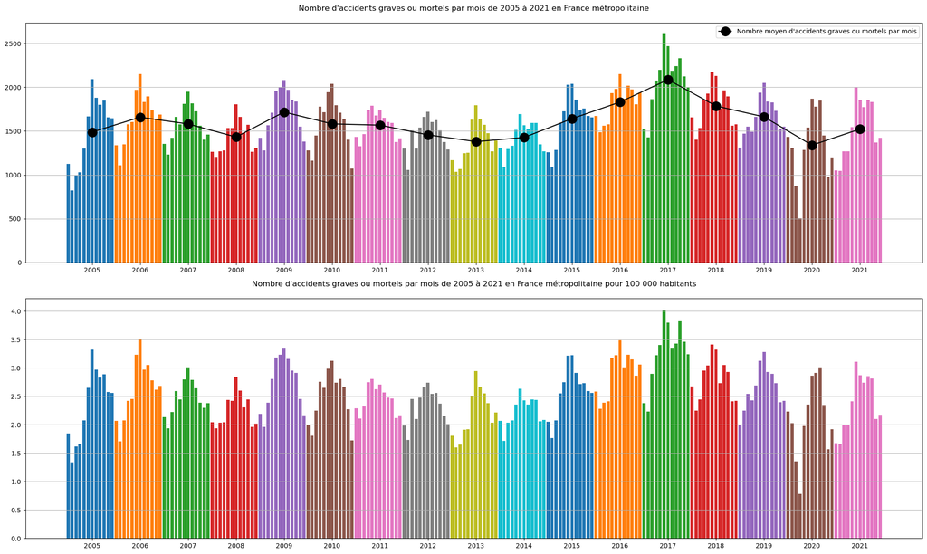

Le nombre d'accidents graves ou mortels suivent la même évolution que le nombre total d'accident pendant la période 2005-2021. Ils sont heureusement très faibles pour 100 000 habitants avec un maximum de 4 blessés graves ou morts par accidents de la route.  
Le graphique ci-dessous permet de comparer ces nombres d'accidents par mois. On note que que les accidents graves ou mortels représentent une forte part des accidents avant 2010. Cette part s'amoindrit dans la décennie de 2010.

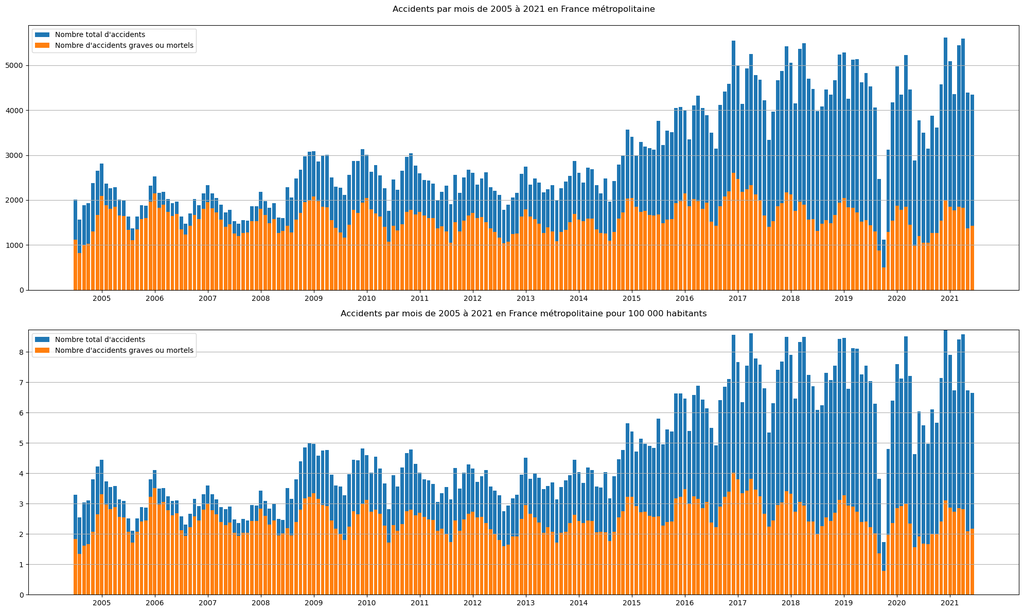

Nous pouvons aussi regarder les proportions d'accidents graves et/ou mortels selon certaines variables. Par exemple, nous regarderons la proportion d'accidents selon le nombre de personnes impliquées et selon le sexe.

### 2.C. Nombre d'usagers impliqués dans les accident

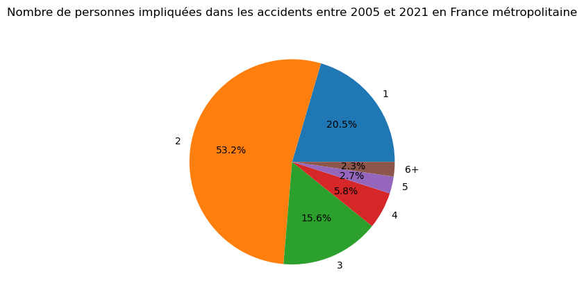

On constate ainisi que plus de la moitié des accidents impliquent seulement 2 personnes, par exemple deux conducteurs ou encore un conducteur et un piéton. Près d'un cinquième des accidents n'implique qu'une personne. Une part très marginale des accidents implique plus de 6 personnes. Il est à noter cependant que dans cette part sont compris les accidents impliquant tout aussi bien 6 personnes que 89.  
Regardons maintenant les proportions d'accidents graves selon le sexe.

### 2.D. Proportion d'hommes et de femmes dans les différents types d'accident

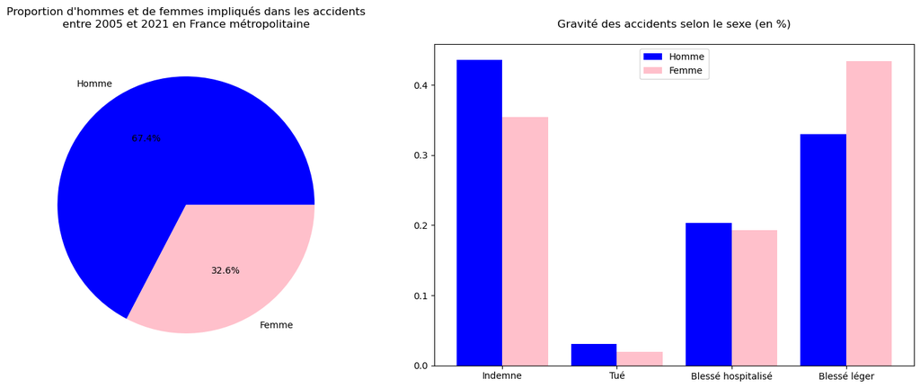

D'après ces données, on remarque qu'il y a plus d'hommes impliqués dans les accidents que de femmes. De plus, les femmes semblent être, en proportion, plus souvent impliquées dans les accidents qui occasionnent des blessures légères. Comme les données sont rapportées aux populations masculine et féminine globales, nous pourrions mal interpréter les résultats. Il est alors intéressant de regarder les proportions d'hommes et de femmes dans les différentes gravités d'accidents selon les années.

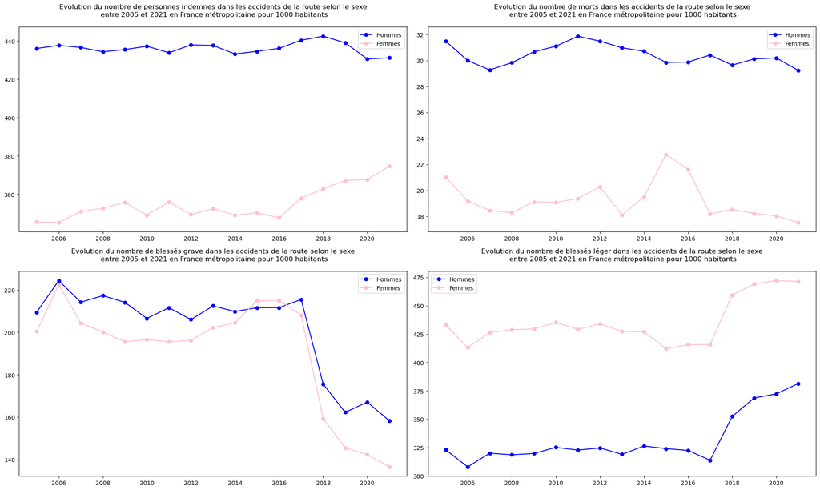

## 3. Régression logistique

Nous allons faire ici une régression logistique avec en variable réponse la modalité de survie ou de mort d'un accidenté. Les modalités '1 – Indemne', '3 – Blessé hospitalisé' et '4 – Blessé léger' sont rassemblées dans une modalité 'Survie = 0' et '2 – Tué' qui représente la modalité 'Deces = 1'. On cherche quels sont les facteurs qui provoquent le plus souvent les decès lors d'un accident.  
Nous considèrerons d'abord les données de l'année 2021.

### 3.A. Sélection préalable des variables

Tout d'abord, on regarde la proportion de valeur manquantes NA pour chaque variable par rapport au nombre de ligne total. Pour la régression logisitque, on ne conservera que celle qui ont une proportion de NA au moins inférieure à 5%. Pour les variables ayant une proportion de NA inférieure à 5% mais supérieure strictement à 0%, on supprimera les lignes comportant ces NA. Cela nous permet de conserver un maximum de lignes et de rendre les résultats meilleurs.

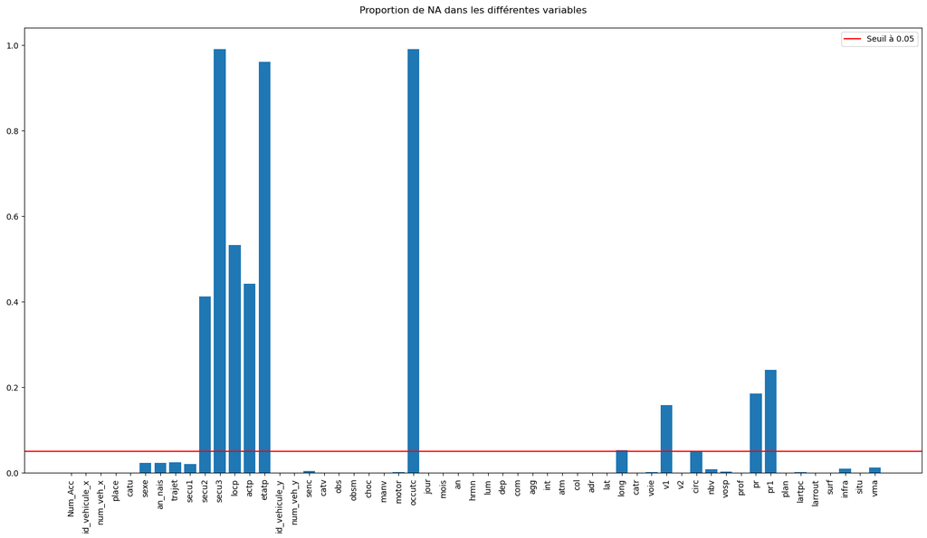

Ainsi, les variables qu'on ne conserve pas sont toutes celles qui ont une valeur supérieure à la droite horizontale rouge, comme `secu2`, `secu3` ou encore `locp`. Par la suite, nous allons devoir transformer toutes nos variables, qui sont toutes catégorielles, en variables indicatrices ($\in \{0,1\}$). Les variables avec énormément de modalités comme `Num_Acc`, `id_vehicule_x`, `num_veh_x`, `id_vehicule_y`, `num_veh_y`, `voie`, `com` ou `adr` n'ont pas été conservées car nous aurions alors trop de variables dans le modèle de régression logistique. De plus, certaines variables présentent peu d'intérêt comme `an`, `lat`, `long`, `jour`, `v2`, `lartpc`, `vma` et `larrout`. En effet, l'année est la même pour tous les accidents, la latitude et la longitude sont différentes pour chaque accident mais on a déja la commune (code postal) et on s'interesse aux accidents en France métropolitaine dans sa globalité.  
Supprimer ces variables avec beaucoup de modalités permet de ne pas allonger les temps de calcul lors de l'éxecution du code de la régréssion logistique. On retire aussi la variables `place` car nous avons la variable `catu` qui représente la cattégorie de l'usagers (Piéton, Conducteur, Passagers).

|  | catu | sexe | an_nais | trajet | secu1 | senc | catv | obs | obsm | choc | ... | col | catr | nbv | vosp | prof | plan | surf | infra | situ | grav |
| --- | --- | --- | --- | --- | --- | --- | --- | --- | --- | --- | --- | --- | --- | --- | --- | --- | --- | --- | --- | --- | --- |
| 0 | 1 | 1 | 2000.0 | 1 | 0 | 1 | 1 | 0 | 2 | 1 | ... | 1 | 3 | 2 | 0 | 1 | 1 | 1 | 0 | 1 | 0 |
| 1 | 1 | 1 | 2000.0 | 1 | 0 | 1 | 7 | 0 | 9 | 3 | ... | 1 | 3 | 2 | 0 | 1 | 1 | 1 | 0 | 1 | 0 |
| 2 | 1 | 1 | 1978.0 | 1 | 1 | 1 | 1 | 0 | 2 | 1 | ... | 1 | 3 | 2 | 0 | 1 | 1 | 1 | 0 | 1 | 0 |
| 3 | 1 | 1 | 1978.0 | 1 | 1 | 1 | 7 | 0 | 9 | 3 | ... | 1 | 3 | 2 | 0 | 1 | 1 | 1 | 0 | 1 | 0 |
| 8 | 1 | 1 | 1995.0 | 1 | 1 | 1 | 7 | 0 | 1 | 3 | ... | 6 | 4 | 2 | 0 | 1 | 1 | 1 | 0 | 1 | 0 |
| ... | ... | ... | ... | ... | ... | ... | ... | ... | ... | ... | ... | ... | ... | ... | ... | ... | ... | ... | ... | ... | ... |
| 234997 | 1 | 1 | 2002.0 | 5 | 1 | 2 | 7 | 0 | 2 | 3 | ... | 1 | 3 | 2 | 0 | 2 | 2 | 2 | 0 | 1 | 0 |
| 234999 | 1 | 1 | 1968.0 | 3 | 1 | 2 | 7 | 0 | 2 | 1 | ... | 1 | 3 | 2 | 0 | 1 | 1 | 2 | 0 | 1 | 0 |
| 235000 | 1 | 1 | 1968.0 | 3 | 1 | 1 | 7 | 0 | 2 | 1 | ... | 1 | 3 | 2 | 0 | 1 | 1 | 2 | 0 | 1 | 0 |
| 235001 | 1 | 1 | 1985.0 | 3 | 1 | 2 | 7 | 0 | 2 | 1 | ... | 1 | 3 | 2 | 0 | 1 | 1 | 2 | 0 | 1 | 0 |
| 235002 | 1 | 1 | 1985.0 | 3 | 1 | 1 | 7 | 0 | 2 | 1 | ... | 1 | 3 | 2 | 0 | 1 | 1 | 2 | 0 | 1 | 0 |

144625 rows × 29 columns

On se retrouve ainsi avec 144625 lignes et 29 colonnes qui ne comportent aucune informations manquantes. Maintenant, nous allons regarder, par des barplot et des histogrammes, quelles sont les variables ayant un effet notable sur notre variable réponse.

### 3.B. Analyse par rapport à la variable réponse binaire

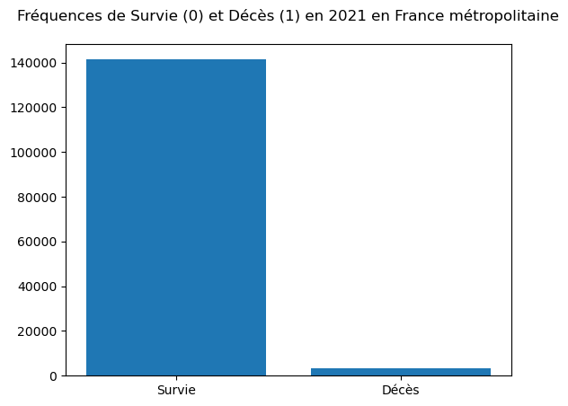

On a des données très déséquilibrées par rapport à la variable réponse `grav` ce qui fait que la régression logistique aura un biais sur les résultats.

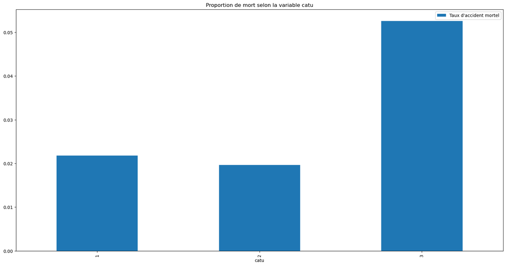

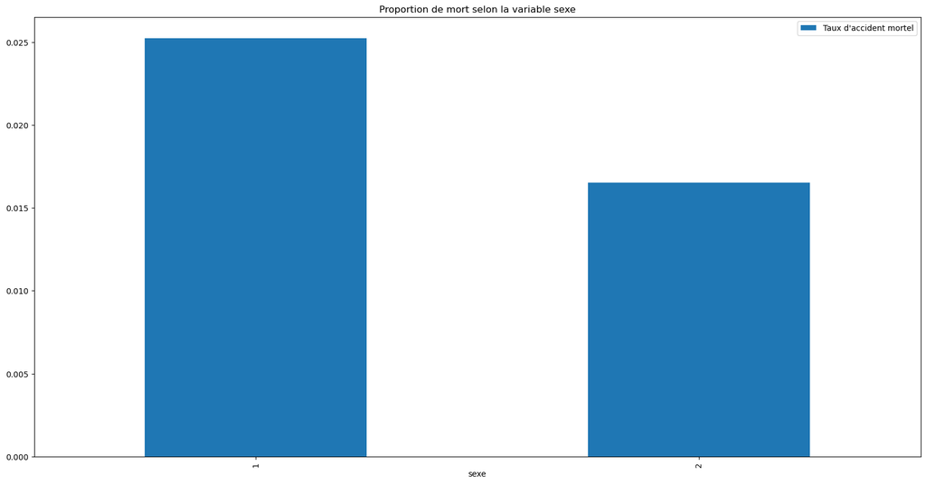

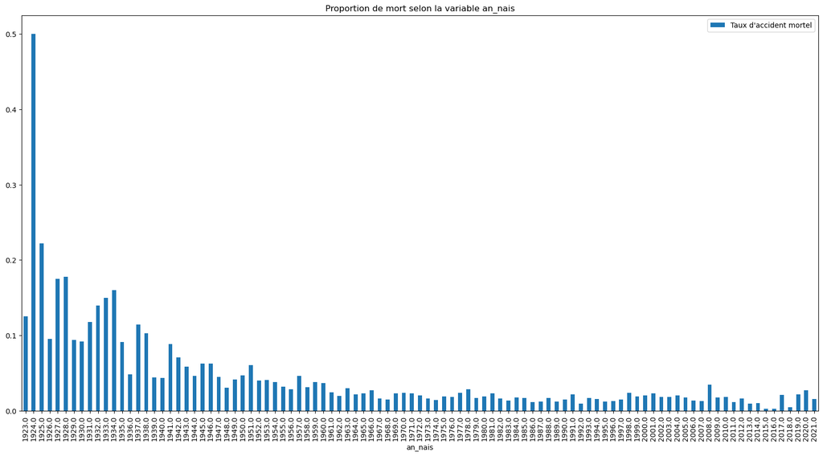

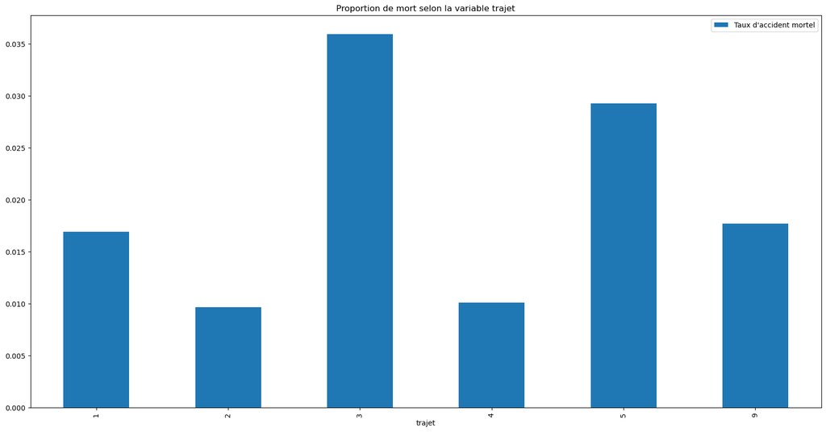

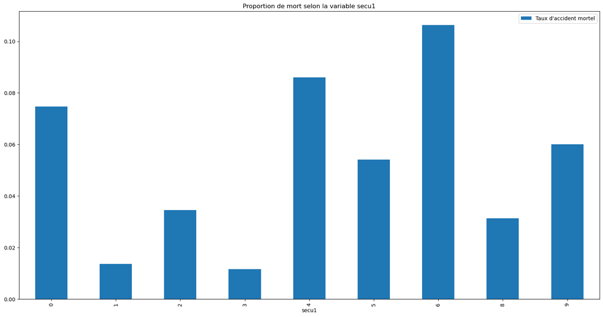

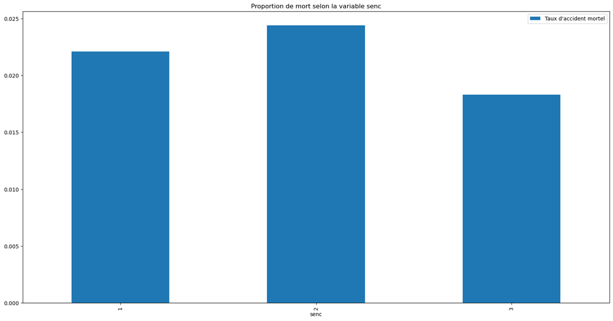

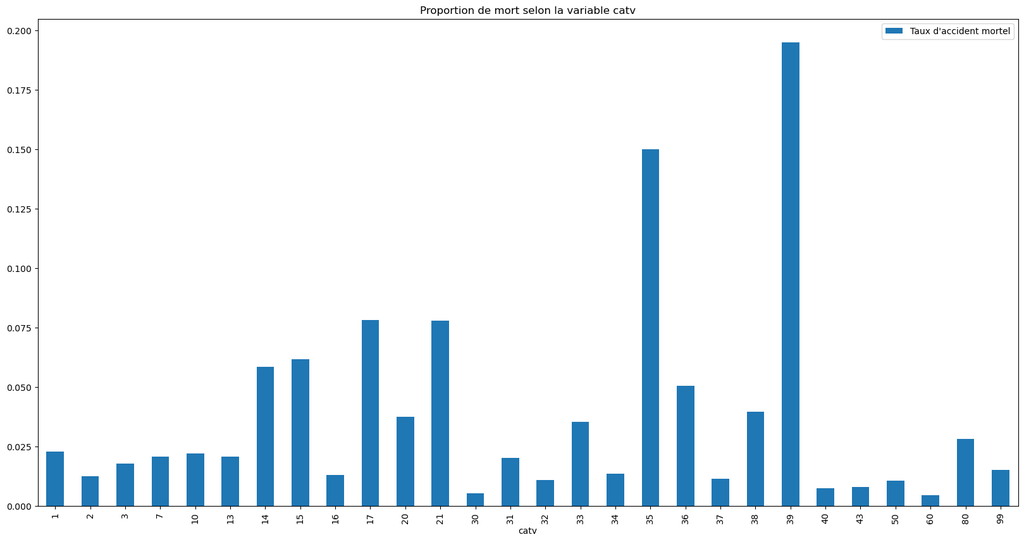

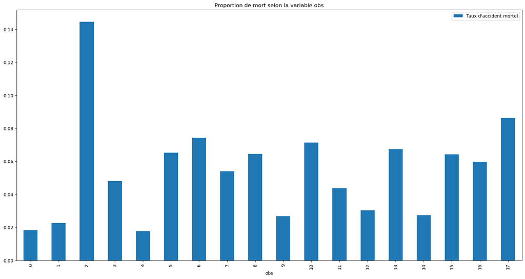

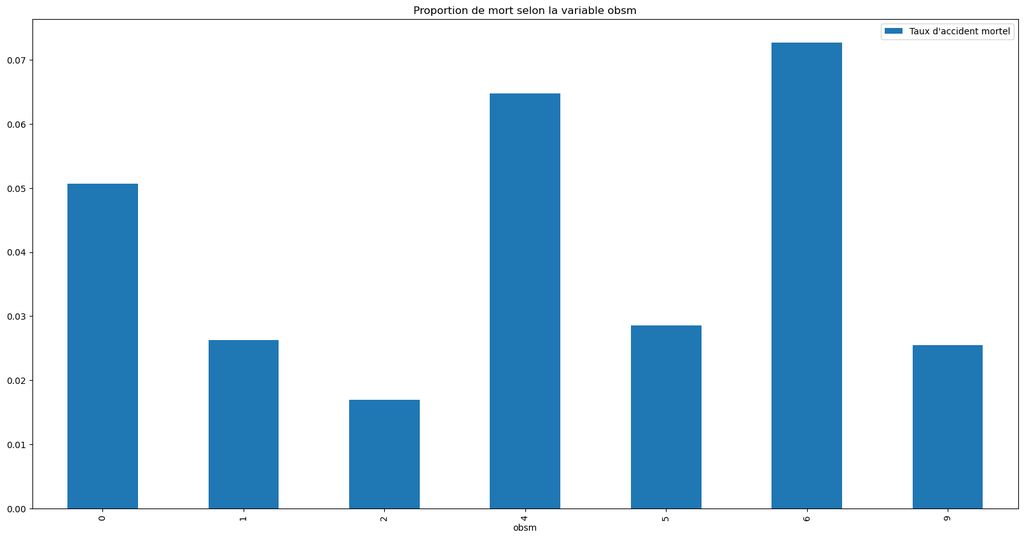

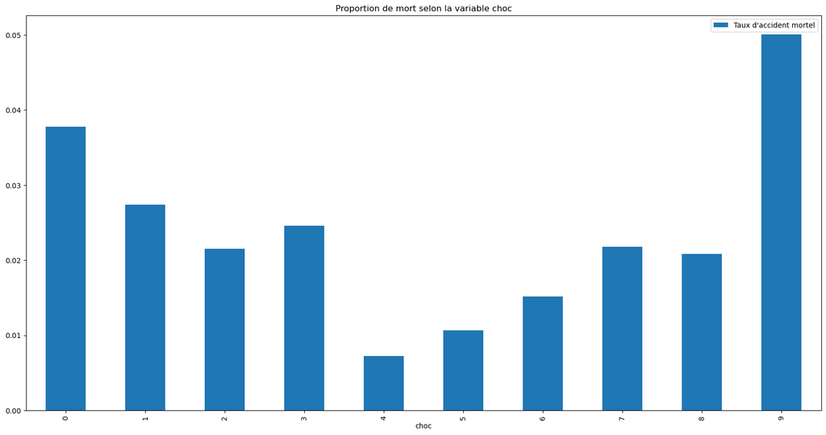

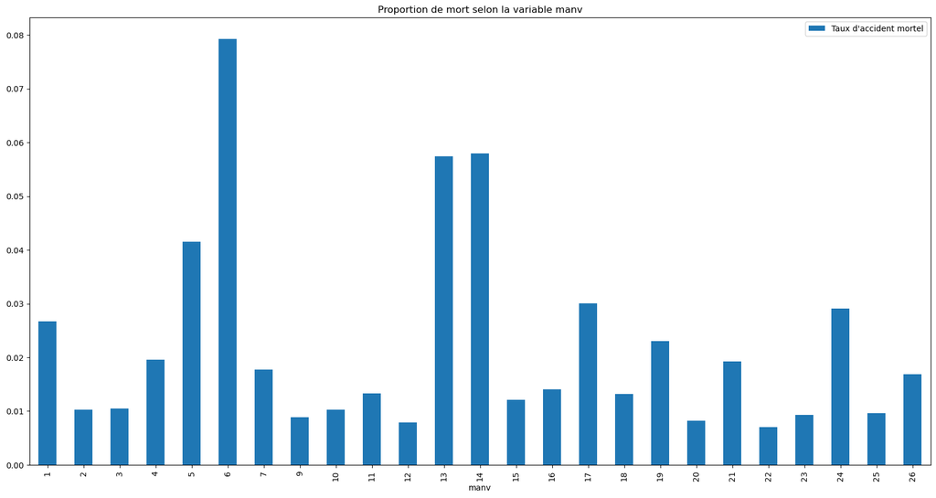

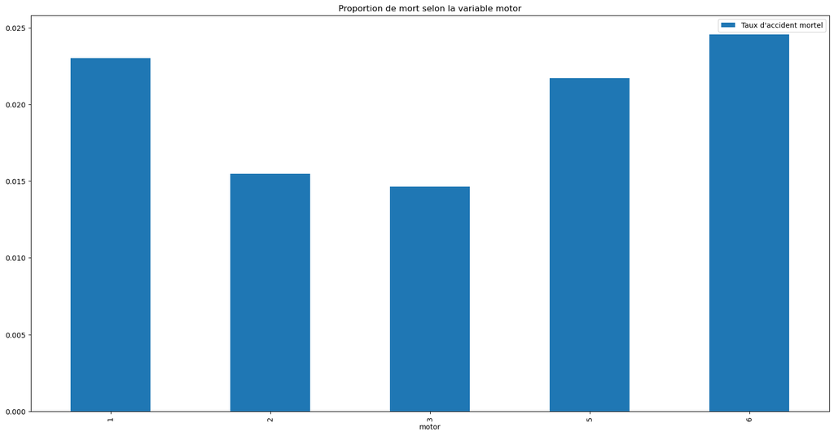

[16 more figures not shown]

Au vu des différences entre modalités, il semblerait que toutes les variables ont un effet sur les decès des usagers.  
Nous allons maintenant appliquer les transformations afin de rendre les variables intérprétables pour la régréssion logistique, i.e. nous allons transformer les variables en variables indicatrices ou "dummies". Les colonnes ne contiendront ainsi que des 1 et des 0.  
Pour des raisons d'interprétation, nous allons transformer la variable `an_nais` en variable `age`, puis nous séparerons par tranche d'age comme suit : 18-24 / 25-34 / 35-44 / 45-54 / 55-64 / 65 et plus.

```
Notre modèle initial comporte 349 variables.
```

### 3.C. Régression logistique sur R

Dans un premier temps, nous avons appliqué [l'algorithme de régression logistique](https://scikit-learn.org/stable/modules/generated/sklearn.linear_model.LogisticRegression.html) de la librairie `scikit-learn`. En raison de problème de convergence de cet algorithme, très probablement dû à l'algorithme d'optimisation utilisé, nous avons décidé de passer sur R.  
On effectue une première régression linéaire avec toutes les variables sélectionnés précédemment et on obtient ce modèle.

```
Call:
glm(formula = grav ~ ., family = binomial(link = "logit"), data = data)

Deviance Residuals:
    Min       1Q   Median       3Q      Max
-1.8235  -0.1933  -0.1069  -0.0587   4.2622

Coefficients:
              Estimate Std. Error z value Pr(>|z|)
(Intercept) -1.497e+00  6.012e-01  -2.490 0.012786 *
catu2       -4.651e-01  5.807e-02  -8.009 1.16e-15 ***
catu3        6.938e-01  1.541e-01   4.503 6.71e-06 ***
sexe2       -2.519e-01  4.805e-02  -5.242 1.59e-07 ***
trajet2     -1.152e+00  1.888e-01  -6.103 1.04e-09 ***
trajet3      5.388e-01  9.609e-02   5.607 2.05e-08 ***
trajet4     -9.673e-01  9.546e-02 -10.133  < 2e-16 ***
trajet5      1.210e-01  6.138e-02   1.971 0.048677 *
trajet9      2.258e-01  8.488e-02   2.661 0.007800 **
secu11      -1.863e+00  7.547e-02 -24.682  < 2e-16 ***
secu12      -1.336e-01  8.371e-02  -1.595 0.110612
secu13      -2.377e+00  2.872e-01  -8.278  < 2e-16 ***
secu14      -4.089e-02  4.107e-01  -0.100 0.920685
secu15      -1.178e+00  7.703e-01  -1.529 0.126274
secu16       2.284e-01  3.057e-01   0.747 0.454918
secu17      -1.351e+01  1.058e+03  -0.013 0.989819
secu18      -7.917e-01  8.760e-02  -9.038  < 2e-16 ***
secu19      -1.005e+00  3.711e-01  -2.710 0.006734 **
senc2        5.047e-02  4.026e-02   1.253 0.210034
senc3        2.852e-02  7.375e-02   0.387 0.698930
catv2       -2.051e+00  5.282e-01  -3.883 0.000103 ***
catv3       -1.082e+00  6.187e-01  -1.748 0.080452 .
catv7       -5.003e-01  5.098e-01  -0.981 0.326359
catv10      -1.072e-01  5.137e-01  -0.209 0.834680
catv13       1.040e-01  5.924e-01   0.175 0.860701
catv14       1.099e+00  5.264e-01   2.088 0.036840 *
catv15       9.880e-01  5.204e-01   1.899 0.057619 .
catv16      -6.332e-01  1.162e+00  -0.545 0.585695
catv17       1.310e+00  5.199e-01   2.520 0.011723 *
catv20       7.014e-02  7.475e-01   0.094 0.925247
catv21       1.869e-01  5.431e-01   0.344 0.730772
```

[output cut: 286 more lines]

```
cat_age2    -5.250e-02  6.946e-02  -0.756 0.449812
cat_age3     2.522e-01  7.124e-02   3.540 0.000400 ***
cat_age4     1.924e-01  7.380e-02   2.607 0.009123 **
cat_age5     5.609e-01  7.303e-02   7.681 1.58e-14 ***
cat_age6     8.492e-01  6.253e-02  13.582  < 2e-16 ***
---
Signif. codes:  0 '***' 0.001 '**' 0.01 '*' 0.05 '.' 0.1 ' ' 1

(Dispersion parameter for binomial family taken to be 1)

    Null deviance: 31180  on 144624  degrees of freedom
Residual deviance: 23698  on 144303  degrees of freedom
AIC: 24342

Number of Fisher Scoring iterations: 15
```

[output not shown]

```
Call:
glm(formula = formule, family = binomial(link = "logit"), data = data)

Deviance Residuals:
    Min       1Q   Median       3Q      Max
-1.8270  -0.1937  -0.1071  -0.0587   4.2767

Coefficients:
              Estimate Std. Error z value Pr(>|z|)
(Intercept) -2.359e+00  3.166e-01  -7.452 9.18e-14 ***
catu2       -4.652e-01  5.801e-02  -8.020 1.06e-15 ***
catu3        6.969e-01  1.540e-01   4.525 6.03e-06 ***
catv2       -1.030e+00  1.698e-01  -6.069 1.29e-09 ***
catv3       -4.373e-02  3.652e-01  -0.120 0.904688
catv7        5.171e-01  1.009e-01   5.123 3.00e-07 ***
catv10       9.071e-01  1.192e-01   7.612 2.71e-14 ***
catv13       1.114e+00  3.203e-01   3.478 0.000506 ***
catv14       2.119e+00  1.653e-01  12.814  < 2e-16 ***
catv15       2.004e+00  1.474e-01  13.591  < 2e-16 ***
catv16       3.608e-01  1.046e+00   0.345 0.730132
catv17       2.320e+00  1.560e-01  14.874  < 2e-16 ***
catv20       1.052e+00  5.508e-01   1.910 0.056119 .
catv21       1.191e+00  2.188e-01   5.445 5.19e-08 ***
catv30      -8.748e-01  2.502e-01  -3.496 0.000471 ***
catv31      -1.780e-01  1.958e-01  -0.909 0.363366
catv32      -8.165e-02  2.179e-01  -0.375 0.707895
catv33       1.421e-01  1.134e-01   1.252 0.210415
catv34      -3.244e-02  2.981e-01  -0.109 0.913338
catv35       1.156e+00  6.800e-01   1.700 0.089162 .
catv36      -1.766e-01  3.731e-01  -0.473 0.635968
catv37       9.824e-01  3.333e-01   2.947 0.003206 **
catv38       1.600e+00  3.322e-01   4.817 1.46e-06 ***
catv39       2.432e+00  5.926e-01   4.104 4.06e-05 ***
catv40       6.002e-01  1.076e+00   0.558 0.577147
catv41      -1.082e+01  9.378e+02  -0.012 0.990791
catv42      -1.250e+01  1.642e+03  -0.008 0.993924
catv43      -3.892e-01  4.033e-01  -0.965 0.334534
catv50       3.565e-01  2.642e-01   1.350 0.177107
catv60      -7.707e-01  1.016e+00  -0.758 0.448195
catv80       7.737e-01  2.646e-01   2.924 0.003457 **
```

[output cut: 269 more lines]

```
situ3        2.870e-01  8.369e-02   3.430 0.000604 ***
situ4        6.781e-01  1.449e-01   4.679 2.88e-06 ***
situ5       -6.719e-01  2.554e-01  -2.631 0.008510 **
situ6       -1.171e+00  3.722e-01  -3.147 0.001648 **
situ8        5.198e-01  1.105e-01   4.704 2.55e-06 ***
---
Signif. codes:  0 '***' 0.001 '**' 0.01 '*' 0.05 '.' 0.1 ' ' 1

(Dispersion parameter for binomial family taken to be 1)

    Null deviance: 31180  on 144624  degrees of freedom
Residual deviance: 23723  on 144320  degrees of freedom
AIC: 24333

Number of Fisher Scoring iterations: 15
```

[output not shown]

Avec la régression logistique, on obtient des coefficients de régression associés à chaque variable dont la nullité est testé avec un test de Wald. Les p-valeurs de ces tests sont affichés dans la dernière colonne du tableau ci-dessus. Pour la plupart des variables, la p-valeur est très faible donc on rejette fortement l'hypothèse de nullité du coefficient, i.e. la variable a un effet notable sur la variable réponse.  
Ainsi, les variables `catu`, `catv`, `cat_age`, `sexe`, `trajet`, `secu1`, `obs`, `obsm`, `choc`, `manv`, `mois`, `hrmn`, `dep`, `int`, `atm`, `agg`, `col`, `catr`, `nbv`, `plan`, `infra`, `surf` et `situ` sont les variables ayant un effet notable sur la variable réponse.  
Puisque les variables sont des indicatrices issues de variables catégorielles, les coefficients de régression sont des logarithmes de rapport de côtes entre une modalité d'une variable et la modalité de référence de la variable.Par exemple pour la variable `atm`, la modalité de référence est 1 : "Conditions atmosphériques normale". Le coefficient de régression associé à `atm2` est négatif, ce qui signifie que le risque de mourir est moins élevé lorsque les conditions atmosphériques sont 2 : "Pluie légère" que si elles sont 1 : "Normales" (toutes choses égales par ailleurs). Au contraire, le coefficient de régression de `atm4` est positif donc le risque de mourir est plus élevé lorsque les conditions atmosphériques sont 4 : "Neiges-grêle" que lorsqu'elles sont 1 : "Normales" (toutes choses égales par ailleurs).  
Maintenant, nous allons séparer les données en données d'entraînement et de test pour voir le taux de précision du modèle précédent.

[output not shown]

```
[1] 0.02368194

pred     0     1
   0 28221   661
   1    24    19
```

IntMatrix with 4 elements.

| 28221 | 24 | 661 | 19 |
| --- | --- | --- | --- |

On introduit la matrice de coûts suivante : $$C = \begin{pmatrix} 0 & 50 \\ 1 & 0 \end{pmatrix}$$

```
[1] "Le risque empirique : "
[1] 0.4346759
[1] "La matrice de confusion est : "

pred_test_r     0     1
          0 21322   113
          1  6923   567
[1] "Le taux de vrai positif est : "
[1] 0.8338235
```

FloatVector with 1 elements.

| 0.833824 |
| --- |

Avec une matrice coût pénalisant 50 fois plus les prédictions 0 en 1 que les 1 en 0, on obtient un risque empirique de 0.43 et un taux de vrai positif à 83%.

## 4. Analyse en Composantes Multiples (ACM)

On va maintenant essayer de faire une Analyse en Composantes Multiples pour sélectionner les variables puis faire une régression logistique avec des variables qualitatives des meilleurs axes de l'ACM. Enfin on comparera les résultats obtenus avec ceux ci-dessus.

ListVector with 5 elements.

[output not shown]

```
Call:
glm(formula = grav ~ ., family = binomial(link = "logit"), data = new_data)

Deviance Residuals:
    Min       1Q   Median       3Q      Max
-4.1013  -0.0001   0.0000   0.0000   6.5068

Coefficients:
             Estimate Std. Error z value Pr(>|z|)
(Intercept) -22.33802    1.28083 -17.440  < 2e-16 ***
`Dim 1`      -1.45410    0.61133  -2.379 0.017379 *
`Dim 2`       8.07968    0.73834  10.943  < 2e-16 ***
`Dim 3`      -3.50437    0.49632  -7.061 1.66e-12 ***
`Dim 4`      -0.39788    0.47381  -0.840 0.401057
`Dim 5`      -0.79465    0.50540  -1.572 0.115878
`Dim 6`       1.90388    0.61355   3.103 0.001915 **
`Dim 7`       0.20163    0.58483   0.345 0.730264
`Dim 8`       2.60169    0.59708   4.357 1.32e-05 ***
`Dim 9`       0.28759    0.59239   0.485 0.627340
`Dim 10`     -0.71441    0.62790  -1.138 0.255213
`Dim 11`     -4.38242    0.68129  -6.433 1.25e-10 ***
`Dim 12`      1.28357    0.62961   2.039 0.041481 *
`Dim 13`      4.40846    0.71154   6.196 5.80e-10 ***
`Dim 14`     -0.50108    0.59618  -0.840 0.400633
`Dim 15`     -1.92061    0.65829  -2.918 0.003527 **
`Dim 16`     -2.88779    0.68088  -4.241 2.22e-05 ***
`Dim 17`      1.01621    0.69580   1.460 0.144158
`Dim 18`      2.88089    0.71574   4.025 5.70e-05 ***
`Dim 19`      3.73162    0.65329   5.712 1.12e-08 ***
`Dim 20`     -1.26610    0.73634  -1.719 0.085531 .
`Dim 21`      7.10236    0.92535   7.675 1.65e-14 ***
`Dim 22`     -1.95319    0.80007  -2.441 0.014635 *
`Dim 23`      1.04335    0.72080   1.448 0.147757
`Dim 24`     -2.31500    0.78343  -2.955 0.003127 **
`Dim 25`      2.59254    0.91121   2.845 0.004439 **
`Dim 26`     -2.18993    0.89948  -2.435 0.014906 *
`Dim 27`     -2.24000    0.66971  -3.345 0.000824 ***
`Dim 28`     -1.87120    0.73630  -2.541 0.011043 *
`Dim 29`     -2.52768    0.78691  -3.212 0.001317 **
`Dim 30`     -0.66966    0.72460  -0.924 0.355390
```

[output cut: 110 more lines]

```
`Dim 141`    -2.40859    0.68947  -3.493 0.000477 ***
`Dim 142`     4.93462    0.83113   5.937 2.90e-09 ***
`Dim 143`    -5.00007    0.72248  -6.921 4.49e-12 ***
`Dim 144`    -4.72824    0.74829  -6.319 2.64e-10 ***
`Dim 145`    -3.39574    0.67740  -5.013 5.36e-07 ***
---
Signif. codes:  0 '***' 0.001 '**' 0.01 '*' 0.05 '.' 0.1 ' ' 1

(Dispersion parameter for binomial family taken to be 1)

    Null deviance: 31180.06  on 144624  degrees of freedom
Residual deviance:   527.37  on 144479  degrees of freedom
AIC: 819.37

Number of Fisher Scoring iterations: 14
```

[output not shown]

```
  [1] "`Dim 1`"   "`Dim 2`"   "`Dim 3`"   "`Dim 6`"   "`Dim 8`"   "`Dim 11`"
  [7] "`Dim 12`"  "`Dim 13`"  "`Dim 15`"  "`Dim 16`"  "`Dim 18`"  "`Dim 19`"
 [13] "`Dim 21`"  "`Dim 22`"  "`Dim 24`"  "`Dim 25`"  "`Dim 26`"  "`Dim 27`"
 [19] "`Dim 28`"  "`Dim 29`"  "`Dim 31`"  "`Dim 33`"  "`Dim 34`"  "`Dim 35`"
 [25] "`Dim 36`"  "`Dim 37`"  "`Dim 38`"  "`Dim 39`"  "`Dim 41`"  "`Dim 42`"
 [31] "`Dim 43`"  "`Dim 44`"  "`Dim 46`"  "`Dim 47`"  "`Dim 48`"  "`Dim 49`"
 [37] "`Dim 50`"  "`Dim 51`"  "`Dim 52`"  "`Dim 53`"  "`Dim 55`"  "`Dim 56`"
 [43] "`Dim 57`"  "`Dim 59`"  "`Dim 60`"  "`Dim 61`"  "`Dim 62`"  "`Dim 63`"
 [49] "`Dim 64`"  "`Dim 65`"  "`Dim 66`"  "`Dim 68`"  "`Dim 70`"  "`Dim 71`"
 [55] "`Dim 73`"  "`Dim 75`"  "`Dim 76`"  "`Dim 77`"  "`Dim 78`"  "`Dim 80`"
 [61] "`Dim 81`"  "`Dim 82`"  "`Dim 83`"  "`Dim 84`"  "`Dim 86`"  "`Dim 87`"
 [67] "`Dim 88`"  "`Dim 93`"  "`Dim 96`"  "`Dim 97`"  "`Dim 98`"  "`Dim 99`"
 [73] "`Dim 100`" "`Dim 101`" "`Dim 102`" "`Dim 103`" "`Dim 104`" "`Dim 105`"
 [79] "`Dim 107`" "`Dim 109`" "`Dim 110`" "`Dim 111`" "`Dim 112`" "`Dim 113`"
 [85] "`Dim 114`" "`Dim 115`" "`Dim 116`" "`Dim 117`" "`Dim 118`" "`Dim 121`"
 [91] "`Dim 122`" "`Dim 123`" "`Dim 126`" "`Dim 127`" "`Dim 130`" "`Dim 132`"
 [97] "`Dim 133`" "`Dim 134`" "`Dim 136`" "`Dim 138`" "`Dim 140`" "`Dim 141`"
[103] "`Dim 142`" "`Dim 143`" "`Dim 144`" "`Dim 145`"
```

StrVector with 106 elements.

| '`Dim 1`' | '`Dim 2`' | '`Dim 3`' | ... | '`Dim 143`' | '`Dim 144`' | '`Dim 145`' |
| --- | --- | --- | --- | --- | --- | --- |

On a donc recupéré les variables à conserver qui sont ci-dessus. On va maintenant faire une régression logistique avec ces variables pour voir si le modèle est mieux.

```
Call:
glm(formula = formule, family = binomial(link = "logit"), data = new_data)

Deviance Residuals:
    Min       1Q   Median       3Q      Max
-4.6889  -0.0003   0.0000   0.0000   6.7605

Coefficients:
            Estimate Std. Error z value Pr(>|z|)
(Intercept) -20.8251     1.0049 -20.724  < 2e-16 ***
`Dim 1`      -1.0157     0.4405  -2.306 0.021125 *
`Dim 2`       7.2082     0.5471  13.176  < 2e-16 ***
`Dim 3`      -3.1005     0.3943  -7.863 3.75e-15 ***
`Dim 6`       1.8904     0.5178   3.651 0.000262 ***
`Dim 8`       2.3158     0.4978   4.652 3.29e-06 ***
`Dim 11`     -4.7283     0.5306  -8.910  < 2e-16 ***
`Dim 12`      1.2714     0.5347   2.378 0.017419 *
`Dim 13`      4.4593     0.5767   7.733 1.05e-14 ***
`Dim 15`     -1.6102     0.4893  -3.291 0.000998 ***
`Dim 16`     -2.0776     0.5170  -4.019 5.85e-05 ***
`Dim 18`      2.3850     0.5946   4.011 6.04e-05 ***
`Dim 19`      3.4090     0.5306   6.425 1.32e-10 ***
`Dim 21`      6.5785     0.7087   9.282  < 2e-16 ***
`Dim 22`     -2.4000     0.6525  -3.678 0.000235 ***
`Dim 24`     -1.7993     0.6175  -2.914 0.003570 **
`Dim 25`      2.5654     0.7052   3.638 0.000275 ***
`Dim 26`     -1.5489     0.7497  -2.066 0.038832 *
`Dim 27`     -2.0289     0.5439  -3.730 0.000191 ***
`Dim 28`     -1.4485     0.5912  -2.450 0.014282 *
`Dim 29`     -1.7914     0.6421  -2.790 0.005272 **
`Dim 31`     -3.7196     0.6279  -5.924 3.14e-09 ***
`Dim 33`     -9.8167     0.7644 -12.843  < 2e-16 ***
`Dim 34`      3.7359     0.6518   5.732 9.94e-09 ***
`Dim 35`     -1.9476     0.5845  -3.332 0.000862 ***
`Dim 36`      5.6545     0.6408   8.824  < 2e-16 ***
`Dim 37`      3.5905     0.6370   5.637 1.73e-08 ***
`Dim 38`      5.7783     0.6748   8.563  < 2e-16 ***
`Dim 39`     -4.7156     0.6566  -7.181 6.90e-13 ***
`Dim 41`     -3.9188     0.6289  -6.231 4.63e-10 ***
`Dim 42`      3.7904     0.6149   6.164 7.07e-10 ***
```

[output cut: 71 more lines]

```
`Dim 141`    -2.2668     0.5966  -3.799 0.000145 ***
`Dim 142`     4.3689     0.5595   7.809 5.76e-15 ***
`Dim 143`    -5.2288     0.5897  -8.866  < 2e-16 ***
`Dim 144`    -3.8591     0.5480  -7.042 1.90e-12 ***
`Dim 145`    -3.1076     0.5486  -5.665 1.47e-08 ***
---
Signif. codes:  0 '***' 0.001 '**' 0.01 '*' 0.05 '.' 0.1 ' ' 1

(Dispersion parameter for binomial family taken to be 1)

    Null deviance: 31180.06  on 144624  degrees of freedom
Residual deviance:   601.88  on 144518  degrees of freedom
AIC: 815.88

Number of Fisher Scoring iterations: 14
```

ListVector with 17 elements.

[output not shown]

Maintenant, nous n'avons plus que des variables ayant un effet significatif sur notre variable réponse et l'AIC est de 815, ce qui est mieux qu'avant. Regardons quel est le taux d'erreur lié à ce modèle.

```
[1] 0.001071737

pred     0     1
   0 28229    17
   1    14   665
```

IntMatrix with 4 elements.

| 28229 | 14 | 17 | 665 |
| --- | --- | --- | --- |

Le taux d'erreur est relativement bas car on arrive très bien à prédire les individus décédés et ceux qui survivent.  
Les 5 variables participant le plus à la construction des axes (dimension 1,2,3 6 et 8) sont ci-dessous.

```
       contribution_variables_dim1
agg_1                     6.902681
catr_1                    6.796449
catr_4                    5.831942
agg_2                     5.700369
col_3                     3.095391
       contribution_variables_dim2
situ_3                    6.387247
obsm_0                    6.230470
col_6                     5.556545
col_7                     3.091779
catr_3                    3.020389
        contribution_variables_dim3
catu_3                    10.919323
obsm_1                    10.560296
col_6                      8.183407
secu1_0                    7.394567
catr_3                     3.146848
        contribution_variables_dim6
motor_5                   15.718360
catv_1                    15.357197
lum_5                      3.872733
choc_0                     3.452995
situ_5                     2.613028
          contribution_variables_dim8
catu_2                       9.099383
trajet_1                     5.446815
trajet_5                     4.914358
cat_age_6                    4.106391
catv_33                      3.218207
```

R/rpy2 DataFrame (5 x 1)

| contribution_variables_dim8 |
| --- |
| ... |

## 5. Prédiction du taux de mortalité

À partir des données sur les accidents des années 2005 à 2021, nous pouvons tenter de prédire quels seront les taux de mortalité des prochaines années.  
La prédiction a été effectué par un package qui utilise l'ACP pour remplacer des valeurs nulles. Il existe différents packages pour remplacer des valeurs NA dans un fichier. On va utiliser le package `missMDA` car il semble être plus performant que le package `mice`. Les résultats renvoyées par la méthode du package `missMDA` n'est pas toujours la même, ainsi, nous allons effectué une moyenne de ces valeurs renvoyées pour faire une prédictions moyenne de ce que seront le nombre de mort en 2022, 2023 et 2024 des accidentés de la route.

FloatMatrix with 60 elements.

| 2005.000000 | 2006.000000 | 2007.000000 | ... | 66016062.871850 | 66293819.985423 | 66571577.098997 |
| --- | --- | --- | --- | --- | --- | --- |

|  | 0 | 1 | 2 |
| --- | --- | --- | --- |
| 0 | 2005.0 | 5543.000000 | 6.096326e+07 |
| 1 | 2006.0 | 4942.000000 | 6.139973e+07 |
| 2 | 2007.0 | 4838.000000 | 6.179524e+07 |
| 3 | 2008.0 | 4443.000000 | 6.213487e+07 |
| 4 | 2009.0 | 4443.000000 | 6.246571e+07 |
| 5 | 2010.0 | 4172.000000 | 6.276524e+07 |
| 6 | 2011.0 | 4111.000000 | 6.307034e+07 |
| 7 | 2012.0 | 3842.000000 | 6.337597e+07 |
| 8 | 2013.0 | 3427.000000 | 6.369786e+07 |
| 9 | 2014.0 | 3557.000000 | 6.402796e+07 |
| 10 | 2015.0 | 3616.000000 | 6.430082e+07 |
| 11 | 2016.0 | 3655.000000 | 6.446879e+07 |
| 12 | 2017.0 | 3600.000000 | 6.463913e+07 |
| 13 | 2018.0 | 3392.000000 | 6.484404e+07 |
| 14 | 2019.0 | 3498.000000 | 6.509677e+07 |
| 15 | 2020.0 | 2780.000000 | 6.528439e+07 |
| 16 | 2021.0 | 3219.000000 | 6.544745e+07 |
| 17 | 2022.0 | 2772.611988 | 6.601606e+07 |
| 18 | 2023.0 | 2642.243165 | 6.629382e+07 |
| 19 | 2024.0 | 2511.874342 | 6.657158e+07 |

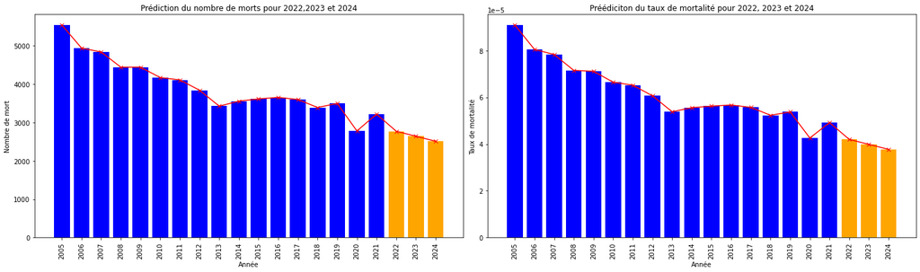

On prédit à partir des données des années passées des taux de mortalité décroissants. Cela suit effectivement la tendance des taux de mortalité à décroître à mesure des années. Cependant, ces résultats sont à prendre avec des pincettes car ils prennent en compte les années 2020 et 2021 qui ont été marquées par le Covid-19 et l'ensemble des restrictions de déplacement qui en ont résulté. De plus, la méthode n'est sans doute pas la meilleur pour ce type de prédiction. Nous aurions pu également utiliser des réseau de neurones (avec les données MCA ou brutes) ou encore des arbres de décision (avec les données MCA ou brutes).

## Conclusion

Au cours de ce projet, nous avons pu mettre en évidence, à partir des données ouvertes sur les accidents de la route, des liens entre le caractère mortel d'un accident et plusieurs facteurs. Cela en utilisant la régression logistique couplée à une sélection de variables par ACM. Ce couplage nous a permis d'obtenir un modèle qui explique le décès ou non d'une personne dans un accident de la route et qui a un AIC bien moindre qu'un modèle sans ACM. Egalement, nous avons pu prédire un taux de mortalité pour les années 2022, 2023 et 2024 décroissant, bien que la méthode de prédiction soit critiquable.  
Enfin, travailler sur ce projet nous a permis de nous ouvrir sur les problématiques des données ouvertes tels le format des données, les données manquantes ou mal enregistrées et la prévalence de variables catégorielles. Ces dernières nous ont rendu difficile le traitement statistique à cause de leur trop grand nombre de modalités.  
Finalement, ce projet nous aura permis de revoir et d'appliquer un grand nombre de notions vu en cours, telles l'analyse et la modélisation statistique, ainsi que d'apprendre de nouveaux outils comme la programmation en R sur Python et l'ACM.